# Bài tập 1

Exercise

R

Author

Thu Pham

Published

July 2, 2025

## Dataset

Dữ liệu `covid_cases.rds` từ [R-Together/day1/data/covid_cases.rds](https://github.com/HCDC-GSCB/swaper/blob/b81a53616702bbac1b39eb04b9d17f966e6b7460/data/covid_cases.rds) sẽ được sử dụng cho bài tập này

**Từ điển dữ liệu**

| Cột | Mô tả |
| --- | --- |
| `date` | Ngày báo cáo của ca bệnh |
| 211 cột với định dạng `cases_{country_code}` | Số trường hợp được báo cáo của mỗi quốc gia và quần đảo |

Mã quốc gia quan tâm (tức là Mã cho các quốc gia cần thiết cho bài tập)

| Code | Tên Quốc gia |
| --- | --- |
| `chn` | China |
| `usa` | United States of America |
| `vnm` | Vietnam |
| `sgp` | Singapore |

## Chuẩn bị

Trước khi thực hiện bài tập này, bạn nên hoàn thành checklist sau

**NoteChecklist**

Trên Github Desktop

- Cloned [R-Together repository](https://github.com/HCDC-GSCB/R-Together)
- Tạo nhánh riêng của bạn trên kho lưu trữ
- Chuyển sang nhánh riêng của bạn

Trên RStudio

- Tạo một R project từ thư mục R-Together

**NoteBài làm**

Bạn cần lưu bài làm của mình tại đường dẫn R-Together/day1/takehome.R

## Bài tập

### Nhiệm vụ 1: Nhập dữ liệu

Đọc dữ liệu từ file `R-Together/day1/data/covid_cases.rds`

### Nhiệm vụ 2: Tính toán đơn giản

Tính toán những điều sau:

- Ngày báo cáo dữ liệu sớm nhất và muộn nhất trong tập dữ liệu và gán chúng cho 2 biến `first_report_date`, `last_report_date`
- Tạo cột mới `case_global` cho `covid_cases`, đại diện cho tổng số trường hợp trên mọi quốc gia mỗi ngày báo cáo.
- Tạo cột mới `percent_chn` trong `covid_cases`, đại diện cho tỷ lệ phần trăm các trường hợp toàn cầu mà các trường hợp Trung Quốc báo cáo trong ngày

**TipGợi ý: tính tổng của từng hàng**

Sử dụng hàm `rowSums()` để tính tổng theo hàng của các cột chứa số ca

**Ví dụ:**

```r
vd_bang <- data.frame(
  a = c(1:3), b = c(4:6)
)
# hiển thị bảng ví dụ
vd_bang
```

```
  a b
1 1 4
2 2 5
3 3 6
```

```r
# Xem kết quả đầu ra của hàm rowSums
rowSums(vd_bang)
```

```
[1] 5 7 9
```

**TipGợi ý: tạo cột mới/cập nhật giá trị của cột**

Để tạo hoặc cập nhật một cột, sử dụng cú pháp `data[["tên_cột"]] <- giá_trị_cho_cột`, trong đó độ dài của `giá_trị_cho_cột` phải bằng với số hàng của bảng dữ liệu.

**Ví dụ:**

```r
vd_bang <- data.frame(
  a = c(1:3), b = c(4:6)
)

# tạo cột mới có tên là new_col
vd_bang[["new_col"]] <- c(7,9,11)
vd_bang
```

```
  a b new_col
1 1 4       7
2 2 5       9
3 3 6      11
```

### Nhiệm vụ 3: **Tạo một function**

Hoàn thành phần sau đây::

- Tạo một function `compute_percent` mà function đó
  - nhận bộ dữ liệu và **mã quốc gia** (3 ký tự sau `cases_` trong tên cột) làm đầu vào.
  - trả về tỷ lệ phần trăm số ca toàn cầu mà số ca của Quốc gia được chỉ định chiếm trên mỗi ngày báo cáo.
- Sử dụng function đó để tạo 3 cột mới cho bảng `covid_cases`: `percent_vnm`, `percent_usa`, `percent_sgp`
- In bảng `covid_cases` cuối cùng, chỉ chọn các cột sau `date`, `percent_chn`, `percent_vnm`, `percent_usa`, `percent_sgp`

**TipGợi ý: nối chuỗi**

Sử dụng function `paste()` để nối nhiều chuỗi lại với nhau

**Ví dụ**

```r
# nối 2 chuỗi
paste("cases_", "chn", sep = "")
```

```
[1] "cases_chn"
```

```r
# nối 3 chuỗi
paste("hello", "world,", "welcome to R-together", sep = " ")
```

```
[1] "hello world, welcome to R-together"
```

### **Nhiệm vụ 3.5 (Tùy chọn): Tạo một hàm từ đoạn mã đã cho**

Tạo môt hàm trả về biểu đồ số ca được báo cáo theo thời gian cho một quốc gia, trong đó người dùng có thể

- Chọn cột số ca cần được vẽ biểu đồ
- Thay đổi tên Quốc gia được hiển thị trên tiêu đề của biểu đồ
- Thay đổi màu của biểu đồ cột và đường
- Thiết lập ngày **nhỏ nhất** và **lớn nhất** (giới hạn trục x) cho biểu đồ

Giả sử đoạn mã để vẽ biểu đồ báo cáo số ca của Trung Quốc như sau

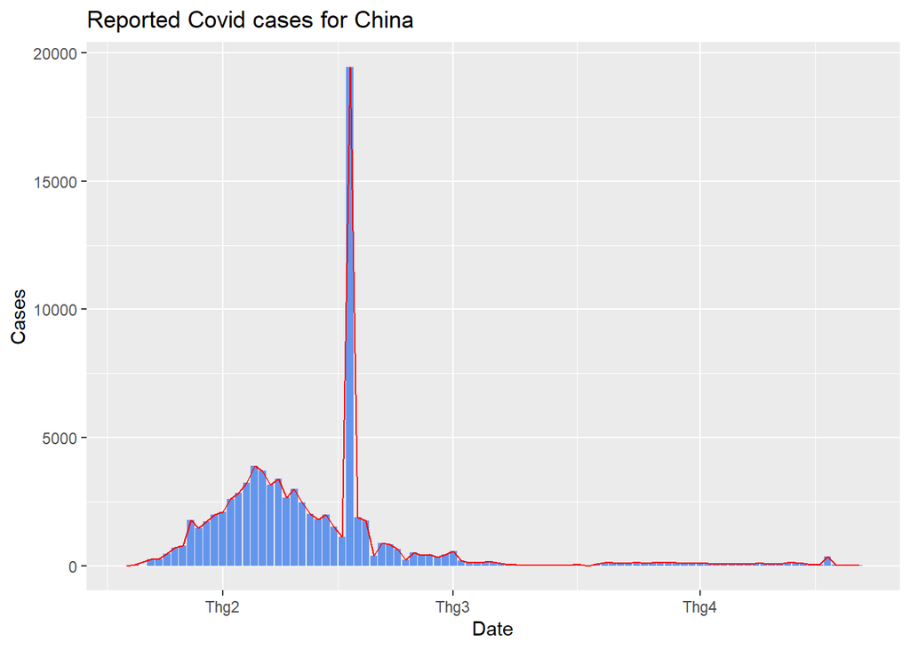

```r
# Bỏ dấu # và chạy đoạn mã sau nếu bạn chưa cài đặt tidyverse hoặc ggplot2
# install.packages("tidyverse")
library(tidyverse)
covid_cases <- read_rds("../data/covid_cases.rds") %>% mutate_if(is.Date, ymd)
library(ggplot2)
plot_col <- "cases_chn"
country <- "China"

ggplot() +
  geom_col( # lớp biểu đồ cột
    aes( # xác định các cột cho trục x, y
      x = covid_cases$date, # điều này tương đương với covid_cases[["date"]]
      y = covid_cases[[plot_col]]
      ),
    fill = "cornflowerblue" # chọn màu cho biểu đồ cột
  ) +
  geom_line( # lớp biểu đồ đường
    aes( # xác định các cột cho trục x, y
      x = covid_cases$date,
      y = covid_cases[[plot_col]]
      ),
    color = "red" # chọn màu cho biểu đồ đường
  ) +
  labs(
    y = "Cases",
    x = "Date",
    title = paste0("Reported Covid cases for ", country) # xác định tiêu đề cho biểu đồ
  )
```

### **Nhiệm vụ 4: Tạo bảng tóm tắt dữ liệu**

Hoàn thành các yêu cầu sau:

- Sử dụng function `skim()` từ package `skimr` để tạo bảng tóm tắt dữ liệu cho các Quốc gia sau: China, Vietnam, USA, Singapore
- Mô tả những quan sát đáng chú ý từ từng Quốc gia dựa trên kết quả của `skim()`

### **Nhiệm vụ 5: Đánh giá**

Hoàn thành các yêu cầu sau:

- Đẩy bài của bạn lên GitHub với nội dung commit: `"day 1 take home solution your_name"`
- Tạo một issue để bình luận về ít nhất **1 bài làm** của 1 người tham gia khác

Back to top